# Stat note

xx

January 8, 2020

# Chi-square test

- degree of freedom = (row - 1)*(col - 1), choose one factor when the other is 1
- critical value

## example 1

flip a conin for 100 time, and it turn out 62 heads and 38 tails. Is it a fair coin?

```r
x = c(HD = 62, TL = 38)
chisq.test(x)
```

```
##
##  Chi-squared test for given probabilities
##
## data:  x
## X-squared = 5.76, df = 1, p-value = 0.0164
```

again, flip a conin for 50 time, and it turn out 28 heads and 22 tails. Is it a fair coin?

```r
x = c(HD = 28, TL = 22)
chisq.test(x)
```

```
##
##  Chi-squared test for given probabilities
##
## data:  x
## X-squared = 0.72, df = 1, p-value = 0.3961
```

## example 2

roll a die 36 times, we got 1:2, 2:4, 3:8, 4:9,5:3, 6:10. Is it a fair die?

```r
x = c(2,4,8,9,3,10)
chisq.test(x)
```

```
##
##  Chi-squared test for given probabilities
##
## data:  x
## X-squared = 9.6667, df = 5, p-value = 0.08525
```

## example 3

observed table

```
##       L  C  R
## up   26 13  5
## down 20 29  7
```

```
##   up down
##   44   56
```

```
##  L  C  R
## 46 42 12
```

A: there are 56 (= 20+29+7) downs, and 42% (=42/(46+42+12)) of C, so 56*42% = 23.52

```
##          L     C     R
## up   20.24 18.48  5.28
## down 25.76 23.52  6.72
```

```r
chisq.test(M)
```

```
##
##  Pearson's Chi-squared test
##
## data:  M
## X-squared = 5.8555, df = 2, p-value = 0.05352
```

# fisher excat test

we can begin with sampling $(x_1,x_2,...,x_n)$ from N has $\frac{N!}{x_1!x_2!..x_n!}$ ways. then for 2 dimensional matrix we have.( you should also it can be extented to higher dimension)

$$P = \frac{R_{1}!R_{2}!...R_{m}!C_{1}!C_{2}!...C_{n}!}{N!a_{11}!a_{12}!...a_{1n}!...a_{21}!...a_{mn}!}$$

```r
chisq.test(M)
```

```
##
##  Pearson's Chi-squared test
##
## data:  M
## X-squared = 5.8555, df = 2, p-value = 0.05352
```

```r
fisher.test(M)
```

```
##
##  Fisher's Exact Test for Count Data
##
## data:  M
## p-value = 0.0466
## alternative hypothesis: two.sided
```

```r
F0 = sum(M)
F1 = c(colSums(M),rowSums(M))
F2 = c(M)
#the configuration probobility is
logP = sum(lfactorial(c(F1))) - sum(lfactorial(c(F0,F2)))
print(exp(logP))
```

```
## [1] 0.002295486
```

# likelihood ratio test

average 3 goals per game? data from 380 games.

```r
goals = c(0,1,2,3,4,5,6,7,8,9)
counts = c(30,79,99,67,61,24,11,6,2,1)
print(data.frame(goals=goals,counts = counts))
```

```
##    goals counts
## 1      0     30
## 2      1     79
## 3      2     99
## 4      3     67
## 5      4     61
## 6      5     24
## 7      6     11
## 8      7      6
## 9      8      2
## 10     9      1
```

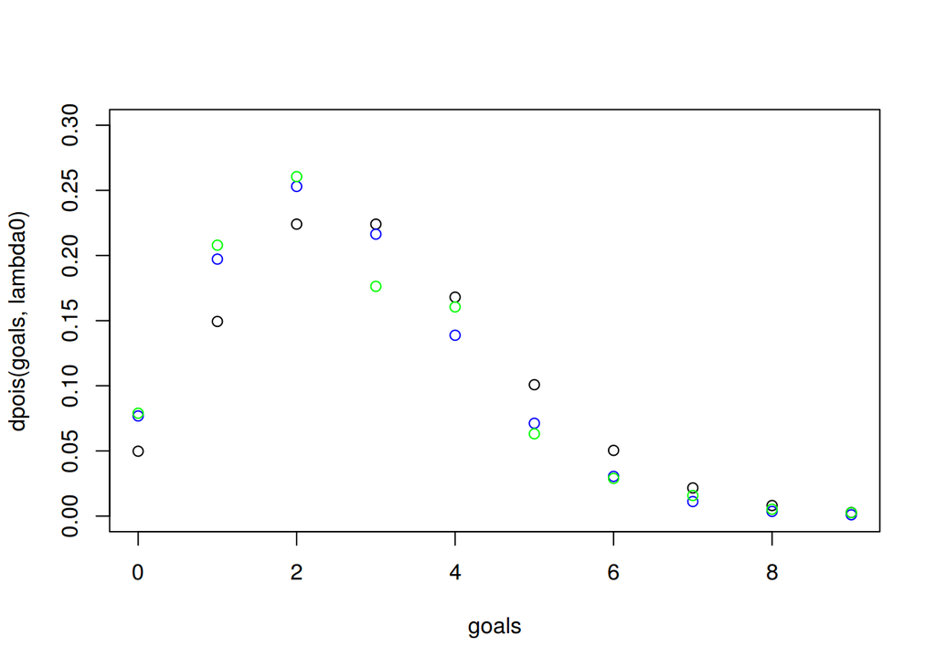

```r
lambda0 = 3
lambda1 = sum(goals*counts/sum(counts))
plot(goals,dpois(goals,lambda0),ylim = c(0,0.3))
points(goals,dpois(goals,lambda1),col = 'blue')
points(goals,counts/sum(counts),col = 'green')
```

With guessed parameter:lambda, the pobobility of see such result is:
$$P = \prod_{i=0}^{380}poisson(x_i,\lambda)$$
$$P = \prod_{gl=0}^{9}possion(goal,\lambda)^n$$
$$LRT = -2*\log(\frac{P_0}{P_1})\sim\chi_{\alpha,1}^2$$

```r
logP = function(lambda) {return(sum(counts*dpois(goals,lambda,log=T)))}

LRT = -2*(logP(lambda0)-logP(lambda1))
cat ("LRT = ",LRT," > ", qchisq(1-0.05,1),"\n")
```

```
## LRT =  25.12516  >  3.841459
```

```r
cat( "p-value = ",1-pchisq(LRT,1),"\n")
```

```
## p-value =  5.372719e-07
```

# Z-test and student t-test

when you know $\mu$ and $\sigma$:
$$Z = \frac{\bar{X}-\mu}{\sigma/\sqrt{n}}\sim N(\mu=0,\sigma=1)$$
when you know $\mu$
$$t = \frac{\bar{X}-\mu}{s/\sqrt{n}} \sim T(\mu=0,df=n-1)$$

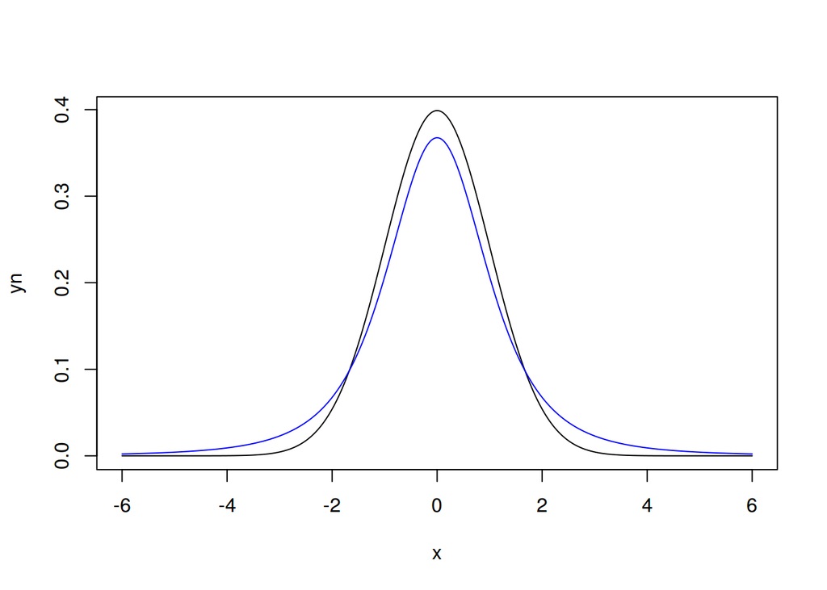

```r
x = seq(-6,6,0.02)
yn = dnorm(x,0,1)
yt = dt(x,3)
plot(x,yn,type = 'l')
points(x,yt,col = 'blue',type = 'l')
```

### Degree of freedom in two samples

the details are not so nice, because there are different ways to deal with the variance, and thus their relative degree of freedom.

#### classical t

$$t = \frac{m_A - m_B}{\sqrt{\frac{s^2}{n_A}+\frac{s^2}{n_B}}}$$
$$s^2=\frac{\sum{(x-m_A)^2}+\sum{(x-m_B)^2}}{n_A+n_B-2}$$
$$df = n_A+n_B-2$$

#### t.test use welch t

$$t = \frac{m_A - m_B}{\sqrt{\frac{s_A^2}{n_A}+\frac{s_B^2}{n_B}}}$$
$$s_A^2=\frac{\sum{(x-m_A)^2}}{n_A-1},s_B^2=\frac{\sum{(x-m_B)^2}}{n_B-1}$$
$$df =\frac{\frac{s_A^2}{n_A}+\frac{s_B^2}{n_B}}{\frac{s_A^2}{n_A^2(n_B-1)}+\frac{s_B^2}{n_B^2(n_A-1)}}$$

```r
t.test(extra~group,data = sleep)
```

```
##
##  Welch Two Sample t-test
##
## data:  extra by group
## t = -1.8608, df = 17.776, p-value = 0.07939
## alternative hypothesis: true difference in means is not equal to 0
## 95 percent confidence interval:
##  -3.3654832  0.2054832
## sample estimates:
## mean in group 1 mean in group 2
##            0.75            2.33
```

```r
data(sleep)
print(sleep)
```

```
##    extra group ID
## 1    0.7     1  1
## 2   -1.6     1  2
## 3   -0.2     1  3
## 4   -1.2     1  4
## 5   -0.1     1  5
## 6    3.4     1  6
## 7    3.7     1  7
## 8    0.8     1  8
## 9    0.0     1  9
## 10   2.0     1 10
## 11   1.9     2  1
## 12   0.8     2  2
## 13   1.1     2  3
## 14   0.1     2  4
## 15  -0.1     2  5
## 16   4.4     2  6
## 17   5.5     2  7
## 18   1.6     2  8
## 19   4.6     2  9
## 20   3.4     2 10
```